# 第一題 [myknn_regressor]

## Q1.1 Create your myknn_regressor based on the skeleton.

myknn_regressor

Goal：Get every x's prediction.

1. Get distance of x with every training data.
2. Sort to get the first k nearest training data. Get k Y_train.
- If "remove_outliers" : remove point out of range[ Q1−1.5*IQR, Q3+1.5*IQR ] IQR=Q3-Q1
1. Ypred = mean(Y_train)

```python
import numpy as np
```

```python
class myknn_regressor():
    def __init__(self, n_neighbors, mean_type):
        """mean_type can be equal_weight or remove_outliers.
                              equal_weight use the same weight for all neighbors.
                              remove_outliers remove neighbors out in [Q1 - 1.5 IQR, Q3 + 1.5IQR]."""
        self.n_neighbors = n_neighbors
        self.mean_type = mean_type
        if n_neighbors < 10:
            self.mean_type = "equal_weight"

    def fit(self, x_train, y_train):
        self.x_train = x_train
        self.y_train = y_train
    def predict(self, x_test):
        """use remove_outliers only if k>=10"""
        # Get every x's prediction.
        ## Get distance of x with every training data.
        ## Sort to get the first k nearest training data. Get k Y_train.
        ## If "remove_outliers" : remove point out of range[ Q1−1.5*IQR, Q3+1.5*IQR ] IQR=Q3-Q1
        ## Ypred = mean(Y_train)
        prediction = []
        for x in x_test:
            dis = []
            neighbors = []
            for i in range(len(self.x_train)):
                dis.append([self.y_train[i], np.linalg.norm(x-self.x_train[i])])
            dis.sort(key = lambda x:x[1])


            neighbors = [dis[j][0] for j in range(self.n_neighbors)]
            if self.mean_type == "remove_outliers":
                q = np.percentile(neighbors, [25, 75])
                iqr = q[1] - q[0]
                neighbors = [dis[j][0] for j in range(self.n_neighbors) \
                             if dis[j][0] >= (q[0]-1.5*iqr) and dis[j][0] <= (q[1]+1.5*iqr)]

            prediction.append(np.mean(neighbors))

        return np.array(prediction)
```

## Q1.2

Load data from msd_data1.pickle.

You should standardize all feature values to have a zero mean and unit variance before training a KNN model.

Make predictions using k=20 and "equal_weight" f.

List the RMSE and the first 20 predictions in the test data.

```python
import pickle
from sklearn import preprocessing
import numpy as np

def load_data(doscaling):
    # Load data
    with open('./msd_data1.pickle', 'rb') as fh1:
        msd_data = pickle.load(fh1)

#     doscaling = 1

    if (doscaling == 1):
        xscaler = preprocessing.StandardScaler().fit(msd_data['X_train'])
        #standardize feature values
        X_train = xscaler.transform(msd_data['X_train'])
        X_test = xscaler.transform(msd_data['X_test'])
    else:
        X_train = msd_data['X_train']
        X_test = msd_data['X_test']

    Y_train = msd_data['Y_train']
    Y_test = msd_data['Y_test']
    return X_train, X_test, Y_train, Y_test
```

```python
doscaling = 1
X_train, X_test, Y_train, Y_test = load_data(doscaling)

n_neighbors = 20
mean_type = "equal_weight"
myknn = myknn_regressor(n_neighbors, mean_type)
myknn.fit(X_train, Y_train)
ypred = myknn.predict(X_test)
```

```python
rmse = np.linalg.norm(ypred - Y_test) / np.sqrt(len(Y_test))
print('RMSE: ',rmse)
```

```
RMSE:  10.251264515495958
```

```python
print('first 20 predictions: ',ypred[:20])
```

```
first 20 predictions:  [1993.35 1993.8  2000.65 1991.5  1992.8  1998.5  1988.1  1991.65 2002.25
 2003.   2000.5  1998.65 1995.55 1997.2  1995.05 1997.4  1992.15 2000.45
 2003.2  1995.75]
```

## Q1.3

Load data from msd_data1.pickle.

Standardized all feature values so that all features have a zero mean and unit variance.

Make predictions using k=20 and "remove_outier" f.

List the RMSE and the first 20 predictions in the testing data.

```python
n_neighbors = 20
mean_type = "remove_outliers"
myknn = myknn_regressor(n_neighbors, mean_type)
myknn.fit(X_train, Y_train)
ypred = myknn.predict(X_test)
```

```python
rmse = np.linalg.norm(ypred - Y_test) / np.sqrt(len(Y_test))
print('RMSE: ',rmse)
```

```
RMSE:  10.212572466080372
```

```python
print('first 20 predictions: ',ypred[:20])
```

```
first 20 predictions:  [1993.35       1993.8        2000.65       1992.73684211 1992.8
 2000.         1988.1        1991.65       2002.25       2003.94736842
 2000.5        2000.94444444 1995.55       1997.2        1998.61111111
 1997.4        1992.15       2003.83333333 2003.2        1995.75      ]
```

# 第二題 [Tuning the Hyper-parameter]

Use the KNN regressor from sklearn.neighbors.KNeighborsRegressor for the first two settings, and your myknn_regressor for the third setting.

For each setting, use the data from msd_data1.pickle to train and test the KNN models.

Compute the RMSE on the testing dataset using k=1,2,3,4,5,10,15,20,25,30,35,40,45,50,55,60,80,100,120,140,160,180,200.

1. In the first case, all feature values are standardized to have unit variances and zero means.
2. As for the second case, do not apply feature scaling.
3. The third case uses standardized features and adopted myknn_regressor with "remove_outlier" f to make predictions.

For each setting, plot a curve that shows the relations between k (x-axis) and RMSE (y-axis).

If possible, plot the three curves in the same figure to visually inspect their dynamics. Discuss your observations.

```python
from sklearn.neighbors import KNeighborsRegressor
k = [1,2,3,4,5,10,15,20,25,30,35,40,45,50,55,60,80,100,120,140,160,180,200]
```

## First Case

```python
doscaling = 1
X_train, X_test, Y_train, Y_test = load_data(doscaling)

rmse1 = []
for n in k:
    knn = KNeighborsRegressor(n_neighbors=n)
    knn.fit(X_train,Y_train)
    y_pred_knn = knn.predict(X_test)
    r = np.linalg.norm(y_pred_knn - Y_test) / np.sqrt(len(Y_test))
    rmse1.append(r)
    print('k: ',n,' rmse: ',r)
```

```
k:  1  rmse:  13.911074724837043
k:  2  rmse:  12.068170946750795
k:  3  rmse:  11.389120864846157
k:  4  rmse:  11.1123354880961
k:  5  rmse:  10.89469289761457
k:  10  rmse:  10.42599891297392
k:  15  rmse:  10.318171959828573
k:  20  rmse:  10.251264515495958
k:  25  rmse:  10.237627225094688
k:  30  rmse:  10.215977156359505
k:  35  rmse:  10.205243203546763
k:  40  rmse:  10.204332770527753
k:  45  rmse:  10.207243171822856
k:  50  rmse:  10.206033712139758
k:  55  rmse:  10.208862384446807
k:  60  rmse:  10.217002627247638
k:  80  rmse:  10.231954198429055
k:  100  rmse:  10.24729594738696
k:  120  rmse:  10.26490845898278
k:  140  rmse:  10.287098382403645
k:  160  rmse:  10.317788599090449
k:  180  rmse:  10.330995620176942
k:  200  rmse:  10.351940397014143
```

## Second Case

```python
doscaling = 0
X_train, X_test, Y_train, Y_test = load_data(doscaling)

rmse2 = []
for n in k:
    knn = KNeighborsRegressor(n_neighbors=n)
    knn.fit(X_train,Y_train)
    y_pred_knn = knn.predict(X_test)
    r = np.linalg.norm(y_pred_knn - Y_test) / np.sqrt(len(Y_test))
    rmse2.append(r)
    print('k: ',n,' rmse: ',r)
```

```
k:  1  rmse:  14.923638966418343
k:  2  rmse:  12.777499755429462
k:  3  rmse:  12.075674967716127
k:  4  rmse:  11.767805657810635
k:  5  rmse:  11.466392632384435
k:  10  rmse:  11.07746090040493
k:  15  rmse:  10.888979137947995
k:  20  rmse:  10.797788546734926
k:  25  rmse:  10.790073017979687
k:  30  rmse:  10.750265612567008
k:  35  rmse:  10.71773871977229
k:  40  rmse:  10.714437504678752
k:  45  rmse:  10.698494013475853
k:  50  rmse:  10.691101059604039
k:  55  rmse:  10.682608734124413
k:  60  rmse:  10.672535729098724
k:  80  rmse:  10.66290751712449
k:  100  rmse:  10.677019504524656
k:  120  rmse:  10.683139638996405
k:  140  rmse:  10.687017556442054
k:  160  rmse:  10.691630026202152
k:  180  rmse:  10.690719783807111
k:  200  rmse:  10.698853374700173
```

## Third Case

```python
doscaling = 1
X_train, X_test, Y_train, Y_test = load_data(doscaling)

rmse3 = []
mean_type = "remove_outliers"
for n in k:
    myknn = myknn_regressor(n, mean_type)
    myknn.fit(X_train, Y_train)
    ypred = myknn.predict(X_test)
    r = np.linalg.norm(ypred - Y_test) / np.sqrt(len(Y_test))
    rmse3.append(r)
    print('k: ',n,' rmse: ',r)
```

```
k:  1  rmse:  13.911074724837043
k:  2  rmse:  12.068170946750795
k:  3  rmse:  11.389120864846157
k:  4  rmse:  11.1123354880961
k:  5  rmse:  10.89469289761457
k:  10  rmse:  10.468549209697086
k:  15  rmse:  10.293424167991523
k:  20  rmse:  10.212572466080372
k:  25  rmse:  10.191475378971328
k:  30  rmse:  10.132105705172412
k:  35  rmse:  10.109608004792982
k:  40  rmse:  10.09323153912292
k:  45  rmse:  10.080018891479625
k:  50  rmse:  10.080783333249329
k:  55  rmse:  10.059767600751961
k:  60  rmse:  10.073857809066581
k:  80  rmse:  10.063683549276588
k:  100  rmse:  10.064917276737452
k:  120  rmse:  10.067237203620246
k:  140  rmse:  10.090646192390134
k:  160  rmse:  10.115316675702926
k:  180  rmse:  10.124987056716318
k:  200  rmse:  10.146220720227745
```

## k-RMSE curve & Discussion

[output not shown]

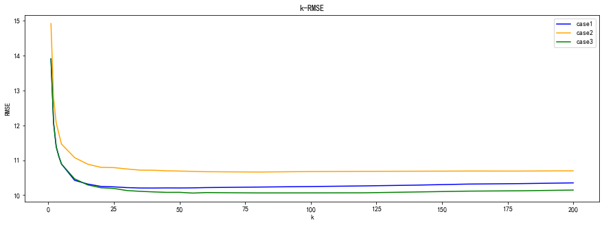

```python
import matplotlib.pyplot as plt
plt.figure(figsize=(15,5))
plt.plot(k, rmse1, color='b', label='case1')
plt.plot(k, rmse2, color='orange', label='case2')
plt.plot(k, rmse3, color='g', label='case3')
plt.title('k-RMSE')
plt.xlabel('k')
plt.ylabel('RMSE')
plt.legend()
plt.show()
```

- Case1. All feature values are standardized to have unit variances and zero means.
- Case2. Do not apply feature scaling.
- Case3. Uses standardized features and adopted myknn_regressor with "remove_outlier" f to make predictions.

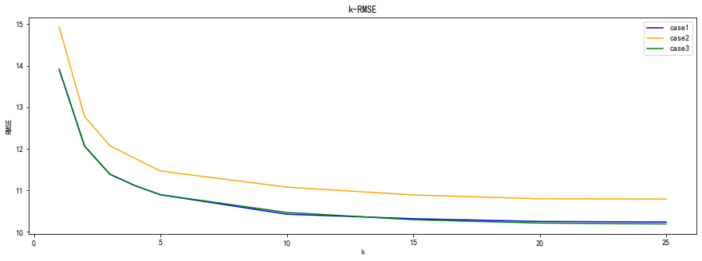

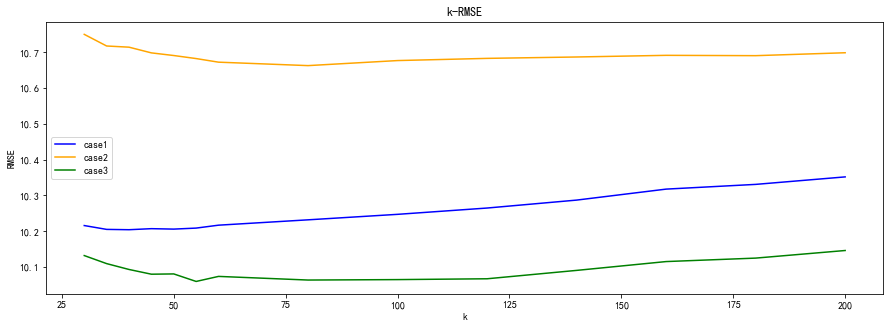

```python
plt.figure(figsize=(15,5))
plt.plot(k[:9], rmse1[:9], color='b', label='case1')
plt.plot(k[:9], rmse2[:9], color='orange', label='case2')
plt.plot(k[:9], rmse3[:9], color='g', label='case3')
plt.title('k-RMSE')
plt.xlabel('k')
plt.ylabel('RMSE')
plt.legend()
plt.show()

plt.figure(figsize=(15,5))
plt.plot(k[9:], rmse1[9:], color='b', label='case1')
plt.plot(k[9:], rmse2[9:], color='orange', label='case2')
plt.plot(k[9:], rmse3[9:], color='g', label='case3')
plt.title('k-RMSE')
plt.xlabel('k')
plt.ylabel('RMSE')
plt.legend()
plt.show()
```

- Case1. All feature values are standardized to have unit variances and zero means.
- Case2. Do not apply feature scaling.
- Case3. Uses standardized features and adopted myknn_regressor with "remove_outlier" f to make predictions.

由結果可見：

- 在Case2沒有進行資料標準化的情況下，不管k為何皆為三種情況下表現最差的，故顯示出資料標準化對於模型效能提升的有效性。
- k<=25的情況下，Case1與Case3的差距不大。
- k>25之後，Case3的表現皆優於Case1，顯示出模型在抓取較多資料為測試資料產生平均值時(k較大時)，剔除掉過於極端的outlier對於模型的效能提升是有幫助的。

故此實驗顯示出資料標準化與移除outlier減少noise皆有助於提升模型效能。

# 第三題 [Lasso Regression]

在開始利用Coordinate Descent with Soft Thresholding更新 w 之前，應先使用Ridge Regression計算出一個初始的 w 。

由這個初始值開始Coordinate Descent with Soft Thresholding更新。細節(如L2 Regularization應設多少之類的)請自行設計。

mylasso的實作應該只會用到numpy以及基本的Python函式。你不應該使用現成的Lasso或Ridge Regression函式(如sklearn.linear_model.Lasso)。

## Q3.1 基於本題給的 L，推導新的Coordinate Descent with Soft Thresholding公式

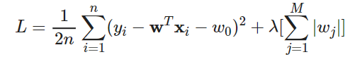

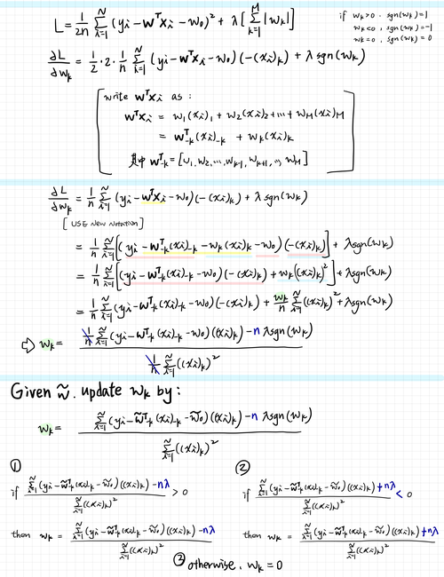

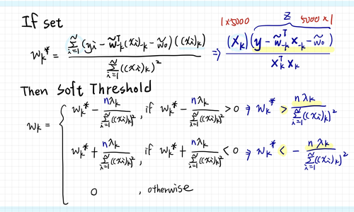

```python
import os, sys
from PIL import Image
basewidth = 500
hsize = 650
img = Image.open('pic_0.jpg')
img = img.resize((basewidth,hsize), Image.ANTIALIAS)
display(img)
basewidth = 500
hsize = 300
img_1 = Image.open('pic_1.jpg')
img_1 = img_1.resize((basewidth,hsize), Image.ANTIALIAS)
display(img_1)
```

## Q3.2 使用給定個骨架建構你的mylasso。

mylasso

Goal：Get the best W

1.Use ridge_regression() to get the initial W

```
* initial X0 with a vector.shape (len(x_train), 1), value=1
* concatnate X0 with x_train
* use the close form solution to generate W：
    W = np.linalg.inv(lamb*I + Xb.T.dot(Xb)).dot(Xb.T).dot(y)
```

2.Use Coordiniate Descent with Soft Thresholding to get the best W

```
* iteration until step(L_last-L) < tol
* call the coor_descent() to get W (k=1~m)
* for every Wk Compute Wk_star using:
    Wk_star = Xk.T*(true_y - (pred_y without W[k]*Xk) - w0) (1,5000)*(5000, 1)
    * call soft_thre() to decide the value of Wk using the formula written in Q3.1(Soft Threshold)
* get the new W
* Calculate L with the new W and get step by abs(L-L_last)
* Record every iteration's Loss and W for Getting the best W of all iterations
```

```python
import numpy as np
import copy

class mylasso():
    def __init__(self, lamcoef, max_iter, tol, const_regu):
        """lamcoef: the regularization coefficient(lambda)
           max_iter: maximum number of iteration for model training
           tol: tolerance for the stopping criteria for model training
           const_regu: whether the constant term should be regularized, default to False
           """
        ### Add your code here ###
        self.lamcoef = lamcoef
        self.max_iter = max_iter
        self.tol = tol
        self.const_regu = const_regu

    def ridge_regression(self, X, y, lamb):
        X0 = np.ones((len(X), 1))
        Xb = np.c_[X0, X]
        I = np.identity(Xb.shape[1])
        I[0][0] = 0
        W = np.linalg.inv(lamb*I + Xb.T.dot(Xb)).dot(Xb.T).dot(y)
        return W.reshape(-1,1), Xb

    def soft_thre(self, Wk_star, lamb):
        if Wk_star > self.n*lamb:
            return Wk_star - self.n*lamb
        elif Wk_star < -(self.n*lamb):
            return Wk_star + self.n*lamb
        else:
            return 0

    def coor_descent(self, W, X, y, lamb):
        for k in range(self.m):
            # Get kth column elememt in Xi (i=1~n): Xk (5000,)-reshape->(5000, 1)
            Xk = X[:,k].reshape(-1,1)
            ypred = np.matmul(X, W)

            # Computing Wk_star = Xk.T*(true_y - (pred_y without W[k]*Xk) - w0) (1,5000)*(5000, 1)
            Wk_star = np.matmul(Xk.T, y - ypred + W[k]*Xk)
#             print(Wk_star)

            ## 處理Loss為 L或L′的狀況
            # not to regularize w0
            if not self.const_regu:
                W[k] = self.soft_thre(Wk_star, lamb)/ (np.matmul(Xk.T, Xk))
            # regularize w0: give W0_star for the initial W0
            elif self.const_regu:
                if k == 0:
                    W[k] = Wk_star/ (np.matmul(Xk.T, Xk))
                else:
                    W[k] = self.soft_thre(Wk_star, lamb)/ (np.matmul(Xk.T, Xk))
        return W #(91, 1)

    def fit(self, x_train, y_train, winit, keep_traindata, verbose):
        """Fit a Lasso model
           x_train: a numpy matrix that contains training features
           y_train: a numpy matrix that contains the label
           winit: how weights are initialized, default to "ridge", ridge regression
           keep_traindata: whether the object is going to keep training data after the training process completed
           verbose: output a lot of message"""
        ## 為了讓結果容易閱讀，請使用np.set_printoptions(suppress=True)關閉Scientific Notation。
        np.set_printoptions(suppress=True)

        ## whether the object is going to keep training data after the training process completed
        if keep_traindata:
            self.x_train = copy.deepcopy(x_train)
            self.y_train = copy.deepcopy(y_train)
        else:
            self.x_train = x_train
            self.y_train = y_train

        self.winit = winit
        self.keep_traindata = keep_traindata
        self.verbose = verbose

        ## how weights are initialized, default to "ridge", ridge regression
        # Initial W by ridge regression
        if winit == "ridge":
            # (91, 1), (5000, 91)
            self.W, self.x_train = self.ridge_regression(self.x_train, self.y_train, self.lamcoef)
            # (5000, 1)
            self.y_train = self.y_train.reshape(-1,1)
        # Initial W by 1
        else:
            X0 = np.ones((len(self.x_train), 1))
            # (5000, 91)
            self.x_train = np.c_[X0, self.x_train]
            # (91, 1)
            self.W = np.ones((self.x_train.shape[1], 1))
            # (5000, 1)
            self.y_train = self.y_train.reshape(-1,1)

        self.m = self.x_train.shape[1] # m dimension
        self.n = self.x_train.shape[0] # n筆資料

        ## Coordiniate Descent with Soft Thresholding
        L_list = []
        W_list = []
        for i in range(self.max_iter):
            # Record the last W for Computing step
            W_last = self.W.copy()

            ## Call the Coordinate Descent with Soft Thresholding function
            # self.W: (91, 1)
            self.W = self.coor_descent(self.W, self.x_train, self.y_train, self.lamcoef)

            ## Computing step
            # self.y_train:(5000,1) - ypred:(5000,91)*(91, 1)->(5000,1) =(5000,1)
            L = np.sum(np.square(self.y_train - np.matmul(self.x_train, W_last)))/(2*len(self.x_train)) \
                + self.lamcoef*(np.sum(abs(W_last)) - W_last[0])
            L_last = np.sum(np.square(self.y_train - np.matmul(self.x_train, self.W)))/(2*len(self.x_train)) \
                + self.lamcoef*(np.sum(abs(self.W)) - self.W[0])

            step = abs(L - L_last)
#             print("step:",step)

#             ## Print Every Iterarion's Result
            if verbose == True:
                np.set_printoptions(suppress=True)
                print("iteration:", i)
                print("Training loss:", L)
                print("RMSE:", np.sqrt(np.mean(np.square(self.y_train - np.matmul(self.x_train, self.W)))))
                print("MAE:", np.mean(abs(self.y_train - np.matmul(self.x_train, self.W))))
                print("Intercept:", self.W[0])
                print("Feature Weights:", self.W[1:].flatten())
                print("非零權重的個數:", np.count_nonzero(self.W[1:].flatten()))

            L_list.append(L)
            W_list.append(self.W)

            ## 每次遞迴之後計算L，如果跟上一個L的改變幅度小於tol，則停止遞迴，回傳過程中最低的L所對應到的權重向量。
            if step < self.tol:
                self.W_final = W_list[L_list.index(min(L_list))]
                np.set_printoptions(suppress=True)
                rmse_final = np.sqrt(np.mean(np.square(self.y_train - np.matmul(self.x_train, self.W_final))))
                mae_final = np.mean(abs(self.y_train - np.matmul(self.x_train, self.W_final)))
                aws = np.mean(abs(self.W_final[1:]))
                non_zero = np.count_nonzero(self.W_final[1:].flatten())

                if verbose == True:
                    print("smaller than tol iter:", i)
                    ## Print The Best Model's Result
                    print("The Best Model Result:")
                    print("Training loss:", min(L_list))
                    print("RMSE:", rmse_final)
                    print("MAE:", mae_final)
                    print("Intercept:", self.W_final[0])
                    print("Feature Weights:", self.W_final[1:].flatten())
                    print("非零權重的個數:", non_zero)

                break
        return min(L_list), rmse_final, mae_final, self.W_final[0], self.W_final[1:].flatten(), non_zero, aws


    def predict(self, x_test):
        """Make prediction using trained model"""
        self.x_test = copy.deepcopy(x_test)
        X0 = np.ones((len(self.x_test), 1))
        # (5000, 91)
        self.x_test = np.c_[X0, self.x_test]
        y_pred = np.matmul(self.x_test, self.W_final)
#         print(y_pred)
        return y_pred.flatten()
```

## Q3.3 載入資料集，並且使用訓練資料計算Lasso Regression的權重，

```python
#load the dataset, and create normalized and raw features.
import pickle
from sklearn import preprocessing
import numpy as np
np.set_printoptions(suppress=True)

#Load data
with open('msd_data1.pickle', 'rb') as fh1:
    msd_data = pickle.load(fh1)

xscaler = preprocessing.StandardScaler().fit(msd_data['X_train'])
#standardize feature values
X_train_sd = xscaler.transform(msd_data['X_train'])
X_test_sd = xscaler.transform(msd_data['X_test'])

#outcome values
Y_train = msd_data['Y_train']
Y_test = msd_data['Y_test']
```

```python
mlo = mylasso(lamcoef = 0.1, max_iter=1000, tol=1e-6, const_regu = False)
l, rmse, mae, inter, weights, non_zero, aws = mlo.fit(X_train, Y_train, winit = "ridge", keep_traindata = True, verbose = False)
print("The Best Model Result:")
print("Training loss:", l[0])
print("RMSE:", rmse)
print("MAE:", mae)
print("Intercept:", inter[0])
print("Feature Weights:", weights)
print("非零權重的個數:", non_zero)
```

```
The Best Model Result:
Training loss: 49.893405098623745
RMSE: 9.720013505274414
MAE: 7.003889367216246
Intercept: 1998.166
Feature Weights: [ 4.6518551  -2.45673153 -1.06195885  0.         -0.34275054 -2.94854329
  0.         -0.39970268 -0.42653866  0.         -0.23498651 -0.39491058
  0.50307719  0.         -0.34207893  0.61674589  0.15722753  0.43489925
  0.43595375  1.12941661  0.40663481  0.          1.77743607  0.
 -0.16842728  0.07833529  0.66391172  0.01297938  0.15350723  0.
 -0.21762074 -0.22189107  0.         -0.0027548  -0.01707674 -0.2599464
  0.          0.28969362  0.34893387  0.         -0.26112569 -0.14488702
 -0.00995271  0.03497723 -0.03984338  0.          0.00299383 -0.17804306
  0.          0.06494382  0.27076506  0.          0.          0.
  0.          0.         -0.63813223  0.23761428 -0.19016387  0.
 -0.18875525  0.         -0.13590668  0.0612754  -0.26619017  0.
  0.          0.         -0.03099184  0.         -0.19276517  0.01221358
  0.20735199  0.25118247  0.12313494  0.          0.         -0.52945662
  0.          0.          0.17859187  0.02408561  0.25291058  0.19360205
  0.37064854  0.          0.         -0.29169753  0.          0.        ]
非零權重的個數: 59
```

## Q3.4 使用上一小題的模型計算測試資料的預測值。列出前五筆資料的預測年分、Test RMSE、Test MAE。

```python
ypred = mlo.predict(X_test)
#列出前五筆資料的預測年分、Test RMSE、Test MAE。
np.set_printoptions(suppress=True)
print("前五筆資料的預測年分: ", ypred[:5])
print("Test RMSE:", np.sqrt(np.mean(np.square(Y_test - ypred))))
print("Test MAE:", np.mean(abs(Y_test - ypred)))
```

```
前五筆資料的預測年分:  [1991.83191145 1998.97198637 2001.66293602 1991.20317029 1994.32657933]
Test RMSE: 9.650076299177927
Test MAE: 6.943728810915765
```

## Q3.5 使用下面的 λ 訓練模型: 0.0001, 0.0005, 0.001, 0.005, 0.01, 0.05, 0.1, 0.5, 1, 2。

記錄每一個 λ 的Training Loss、Number of Nonzero Weights、Average Weight Size (Mean of Absolute Weight)、Training RMSE、Test RMSE。

將所有的結果列表、畫折線圖、並寫下你對結果的觀察。

```python
import pandas as pd
lamb_list = [0.0001, 0.0005, 0.001, 0.005, 0.01, 0.05, 0.1, 0.5, 1, 2]
L = []
RMSE_train = []
RMSE_test = []
AWS = []
Non_zero = []

for lamb in lamb_list:
    mlo = mylasso(lamcoef = lamb, max_iter=1000, tol=1e-6, const_regu = False)
    l, rmse, mae, inter, weights, non_zero, aws = mlo.fit(X_train, Y_train, winit = "ridge", keep_traindata = True, verbose = False)
    ypred = mlo.predict(X_test)
    rmse_test = np.sqrt(np.mean(np.square(Y_test - ypred)))
    L.append(l[0])
    Non_zero.append(non_zero)
    AWS.append(aws)
    RMSE_train.append(rmse)
    RMSE_test.append(rmse_test)

df_result = pd.DataFrame()
df_result["lambda"] = lamb_list
df_result["Training Loss"] = L
df_result["Number of Nonzero Weights"] = Non_zero
df_result["Average Weight Size"] = AWS
df_result["Training RMSE"] = RMSE_train
df_result["Test RMSE"] = RMSE_test
```

```python
np.set_printoptions(suppress=True)
display(df_result)
```

|  | lambda | Training Loss | Number of Nonzero Weights | Average Weight Size | Training RMSE | Test RMSE |
| --- | --- | --- | --- | --- | --- | --- |
| 0 | 0.0001 | 46.570462 | 90 | 0.470656 | 9.650516 | 9.644375 |
| 1 | 0.0005 | 46.587380 | 90 | 0.469507 | 9.650518 | 9.644096 |
| 2 | 0.0010 | 46.608462 | 90 | 0.467906 | 9.650528 | 9.643547 |
| 3 | 0.0050 | 46.774670 | 89 | 0.455754 | 9.650863 | 9.640108 |
| 4 | 0.0100 | 46.976877 | 87 | 0.442903 | 9.651763 | 9.636501 |
| 5 | 0.0500 | 48.418641 | 76 | 0.363977 | 9.672719 | 9.627055 |
| 6 | 0.1000 | 49.893405 | 59 | 0.294897 | 9.720014 | 9.650076 |
| 7 | 0.5000 | 56.500689 | 16 | 0.120031 | 10.109331 | 10.021195 |
| 8 | 1.0000 | 60.389324 | 4 | 0.042175 | 10.638945 | 10.548061 |
| 9 | 2.0000 | 63.492131 | 1 | 0.004266 | 11.200386 | 11.141073 |

### Plot

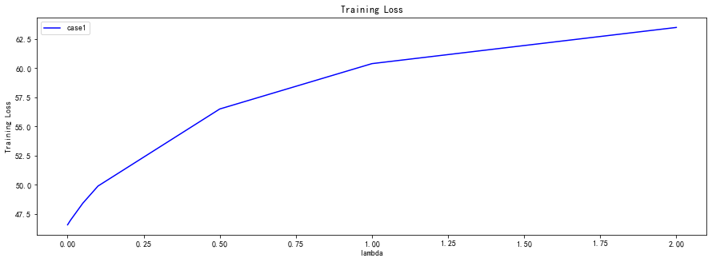

```python
plt.figure(figsize=(15,5))
plt.plot(df_result["lambda"], df_result["Training Loss"], color='b', label='case1')
plt.title('Training Loss')
plt.xlabel('lambda')
plt.ylabel('Training Loss')
plt.legend()
plt.show()
```

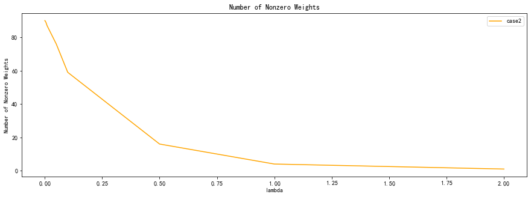

```python
plt.figure(figsize=(15,5))
plt.plot(df_result["lambda"], df_result["Number of Nonzero Weights"], color='orange', label='case2')
plt.title('Number of Nonzero Weights')
plt.xlabel('lambda')
plt.ylabel('Number of Nonzero Weights')
plt.legend()
plt.show()
```

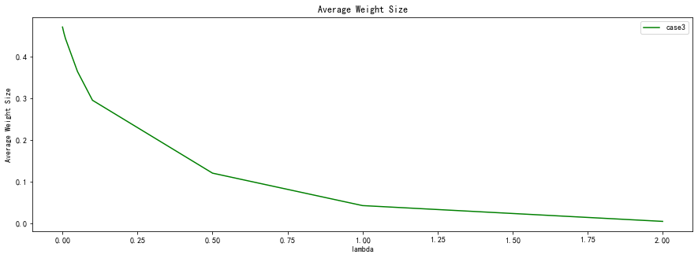

```python
plt.figure(figsize=(15,5))
plt.plot(df_result["lambda"], df_result["Average Weight Size"], color='g', label='case3')
plt.title('Average Weight Size')
plt.xlabel('lambda')
plt.ylabel('Average Weight Size')
plt.legend()
plt.show()
```

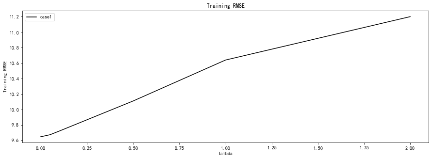

```python
plt.figure(figsize=(15,5))
plt.plot(df_result["lambda"], df_result["Training RMSE"], color='black', label='case1')
plt.title('Training RMSE')
plt.xlabel('lambda')
plt.ylabel('Training RMSE')
plt.legend()
plt.show()
```

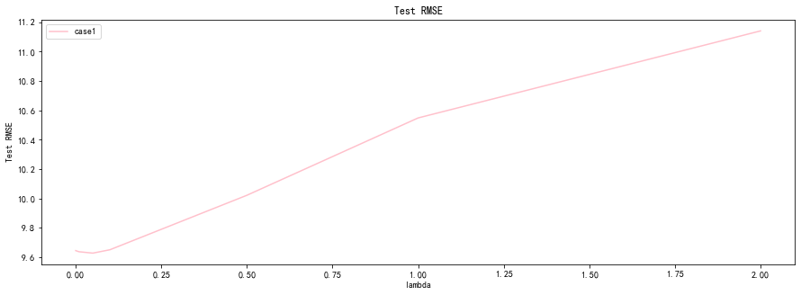

```python
plt.figure(figsize=(15,5))
plt.plot(df_result["lambda"], df_result["Test RMSE"], color='pink', label='case1')
plt.title('Test RMSE')
plt.xlabel('lambda')
plt.ylabel('Test RMSE')
plt.legend()
plt.show()
```

### Discussion

由結果可見：

當lambda越大時，Training Loss、Training RMSE皆跟著上升，使得表現較差。

當lambda<=0.001時，所有特徵所對應的weights都為非零值，可見lambda值較小時比較不會以極端的方式進行特徵篩選(將值=0)。

然而可發現在lambda=0.05時，非零權重為76個，並具有最佳的Testing RMSE=9.627055。

且lambda<0.05的情況下，lambda值越小：

- Testing RMSE不減反升，顯示出模型overfitting的情況越來越嚴重。
- 非零權重數量越來越多，顯示regularization term的效果減弱，模型複雜度升高，也進而導致overfitting。

故並非lambda值越小越好，有一定大小的lambda進行特徵篩選後，可以降低模型複雜度也降低overfiting的程度，在特徵量與筆數相對不多的情況下反而能有更好的表現。